# Week 2 - Basic Big Data with RDD, Data Frames, SQL, and MLlib

**Lecturer: Nang Nguyen**

## 2.1. Basic Big Data and Functional Programming

### 2.1.1. Understanding Spark Context

```python
from pyspark import SparkConf, SparkContext
import collections

# Configure and initialize Spark
conf = SparkConf().setMaster("local").setAppName("RatingsHistogram")
sc = SparkContext(conf = conf)
```

```python
# Version indicates the current running version of spark
sc.version
```

```
'3.5.1'
```

```python
# Python Version reveals the version of Python that Spark is utilizing.
sc.pythonVer
```

```
'3.10'
```

```python
# Master specifies the cluster URL or indicates "local" mode.
sc.master
```

```
'local'
```

**Loading data in Pyspark**  
i. **parallelize Method:** Distributes a Python list across a Spark cluster, useful for small datasets or testing.

```python
rdd = sc.parallelize([1,2,3,4,5])
rdd
```

```
ParallelCollectionRDD[0] at readRDDFromFile at PythonRDD.scala:289
```

ii. **textFile Method:** Loads data from external text files into Spark, suitable for larger, file-based datasets.

```python
rdd2 = sc.textFile("data/1800.csv")
rdd2
```

```
data/1800.csv MapPartitionsRDD[2] at textFile at NativeMethodAccessorImpl.java:0
```

### 2.1.2. Functional Programming in Python

```python
square = lambda x: x*x
print(square(3))
```

```
9
```

```python
def cube(x):
    return x**3
g = lambda x: x**3
print(g(10))
print(cube(10))
```

```
1000
1000
```

- No return statement for lambda
- Lambda functions are anonymous
- Can put lambda function anywhere

```python
items=[1,2,3,4]
list(map(lambda x: x+2, items))
```

```
[3, 4, 5, 6]
```

- often use in conjunction with built-in function like map and filter
- applied a specifed function to all items in a list, returning a new list with the results
- syntax for map: **map(function, list)**

```python
items=[1,2,3,4]
list(filter(lambda x: (x%2 !=0), items))
```

```
[1, 3]
```

## 2.2. RDD

```python
type(rdd)
```

```
pyspark.rdd.RDD
```

```python
type(rdd2)
```

```
pyspark.rdd.RDD
```

```python
helloRDD=sc.parallelize("Hello World")
type(helloRDD)
```

```
pyspark.rdd.RDD
```

```python
# Create the RDD with specified number of partitions
numRDD = sc.parallelize(range(10), 6) # 6 is the number of partitions

# Get the number of partitions
num_partitions = numRDD.getNumPartitions()

print(f"Number of partitions: {num_partitions}")
```

```
Number of partitions: 6
```

### Transformation and Action

**Transformation**

Already knew map(), and filter() function  
Now, flatMap() function

```python
# Sample data: list of sentences
sentences = ["Hello world", "Apache Spark is great", "FlatMap is powerful"]

# Create an RDD from the sample data
sentencesRDD = sc.parallelize(sentences)

# Use flatMap to split each sentence into words
wordsRDD = sentencesRDD.flatMap(lambda sentence: sentence.split(" "))

# Collect the results
words = wordsRDD.collect()

print(f"Words: {words}")
```

```
Words: ['Hello', 'world', 'Apache', 'Spark', 'is', 'great', 'FlatMap', 'is', 'powerful']
```

The flatMap transformation is used to split each sentence into words. The lambda function lambda sentence: sentence.split(" ") splits each sentence into a list of words. The flatMap transformation then flattens these lists into a single RDD of words.

```python
# Create two sample RDDs
rdd1 = sc.parallelize([1, 2, 3, 4, 5])
rdd2 = sc.parallelize([4, 5, 6, 7, 8])

# Use union to combine the two RDDs
unionRDD = rdd1.union(rdd2)

# Collect the results
result = unionRDD.collect()

print(f"Union of rdd1 and rdd2: {result}")
```

```
Union of rdd1 and rdd2: [1, 2, 3, 4, 5, 4, 5, 6, 7, 8]
```

**Actions**

```python
# Create an RDD from a list of integers
rdd = sc.parallelize([1, 2, 3, 4, 5, 6, 7, 8, 9, 10])

# Collect the entire RDD to a list
data = rdd.collect()
print(f"Collect: {data}")

# Take the first 5 elements from the RDD
first_five = rdd.take(5)
print(f"Take 5: {first_five}")

# Get the first element of the RDD
first_element = rdd.first()
print(f"First element: {first_element}")

# Count the number of elements in the RDD
total_elements = rdd.count()
print(f"Total elements: {total_elements}")
```

```
Collect: [1, 2, 3, 4, 5, 6, 7, 8, 9, 10]
Take 5: [1, 2, 3, 4, 5]
First element: 1
Total elements: 10
```

**Pair RDDs in PySpark** (also known as key-value RDDs)

```python
# Create a paired RDD
pairs = sc.parallelize([("a", 1), ("b", 2), ("a", 2), ("b", 3)])

# Use reduceByKey to sum values with the same key
reduced = pairs.reduceByKey(lambda x, y: x + y)

# Collect and print the result
result = reduced.collect()
print(f"reduceByKey result: {result}")
```

```
reduceByKey result: [('a', 3), ('b', 5)]
```

```python
# Use groupByKey to group values by key
grouped = pairs.groupByKey()

# Collect and print the result
result = grouped.mapValues(list).collect()
print(f"groupByKey result: {result}")
```

```
groupByKey result: [('a', [1, 2]), ('b', [2, 3])]
```

```python
# Use sortByKey to sort the RDD by key
sorted_rdd = pairs.sortByKey()

# Collect and print the result
result = sorted_rdd.collect()
print(f"sortByKey result: {result}")
```

```
sortByKey result: [('a', 1), ('a', 2), ('b', 2), ('b', 3)]
```

```python
# Create two paired RDDs
rdd1 = sc.parallelize([("a", 1), ("b", 2)])
rdd2 = sc.parallelize([("a", 3), ("b", 4), ("a", 5)])

# Use join to join the two RDDs by key
joined = rdd1.join(rdd2)

# Collect and print the result
result = joined.collect()
print(f"join result: {result}")
```

```
join result: [('b', (2, 4)), ('a', (1, 3)), ('a', (1, 5))]
```

**Advanced RDD Actions**  
reduce() action

```python
# Create an RDD from a list of integers
rdd = sc.parallelize([1, 2, 3, 4, 5, 6, 7, 8, 9, 10])

# Use reduce to sum all the elements of the RDD
sum_of_elements = rdd.reduce(lambda x, y: x + y)

# Print the result
print(f"Sum of elements: {sum_of_elements}")
```

```
Sum of elements: 55
```

```python
# Create a paired RDD
pairs = sc.parallelize([("apple", 10), ("banana", 20), ("orange", 15)])

# Use collectAsMap to retrieve the RDD as a dictionary
result_dict = pairs.collectAsMap()

# Print the result
print(f"Result as dictionary: {result_dict}")
```

```
Result as dictionary: {'apple': 10, 'banana': 20, 'orange': 15}
```

```python
# Create a paired RDD
items = sc.parallelize([
    ("fruit", "apple"),
    ("fruit", "banana"),
    ("vegetable", "carrot"),
    ("fruit", "orange"),
    ("vegetable", "pepper"),
    ("fruit", "banana")
])

# Use countByKey to count the number of elements for each key
counts = items.countByKey()

# Print the result
print(f"Count by key: {counts}")
```

```
Count by key: defaultdict(<class 'int'>, {'fruit': 4, 'vegetable': 2})
```

## 2.3. PySpark SQL & DataFrame

### 2.3.1. Abstracting Data with DataFrame

```python
from pyspark.sql import SparkSession

# Initialize SparkSession
spark = SparkSession.builder.appName("CreateDataFrameFromRDD").getOrCreate()

# Create an RDD
iphones_RDD = spark.sparkContext.parallelize([
    ("XS", 2018, 5.65, 2.79, 6.24),
    ("XR", 2018, 5.94, 2.98, 6.84),
    ("X10", 2017, 5.65, 2.79, 6.13),
    ("8Plus", 2017, 6.23, 3.07, 7.12)
])

# Define the schema
names = ['Model', 'Year', 'Height', 'Width', 'Weight']

# Create a DataFrame
iphones_df = spark.createDataFrame(iphones_RDD, schema=names)

# Display the type of iphones_df
print(type(iphones_df))

# Show the DataFrame
iphones_df.show()
```

```
<class 'pyspark.sql.dataframe.DataFrame'>
+-----+----+------+-----+------+
|Model|Year|Height|Width|Weight|
+-----+----+------+-----+------+
|   XS|2018|  5.65| 2.79|  6.24|
|   XR|2018|  5.94| 2.98|  6.84|
|  X10|2017|  5.65| 2.79|  6.13|
|8Plus|2017|  6.23| 3.07|  7.12|
+-----+----+------+-----+------+
```

```python
from pyspark.sql.types import StructType, StructField, IntegerType, StringType

# Initialize SparkSession
spark = SparkSession.builder.appName("ReadMovieLensData").getOrCreate()

# Define the schema for the u.data file
schema = StructType([
    StructField("user_id", IntegerType(), True),
    StructField("item_id", IntegerType(), True),
    StructField("rating", IntegerType(), True),
    StructField("timestamp", StringType(), True)
])

# Read the data from the file
df_ratings = spark.read.csv("data/ml-100k/u.data", sep='\t', schema=schema)

# Show the DataFrame
df_ratings.show()
```

```
+-------+-------+------+---------+
|user_id|item_id|rating|timestamp|
+-------+-------+------+---------+
|    196|    242|     3|881250949|
|    186|    302|     3|891717742|
|     22|    377|     1|878887116|
|    244|     51|     2|880606923|
|    166|    346|     1|886397596|
|    298|    474|     4|884182806|
|    115|    265|     2|881171488|
|    253|    465|     5|891628467|
|    305|    451|     3|886324817|
|      6|     86|     3|883603013|
|     62|    257|     2|879372434|
|    286|   1014|     5|879781125|
|    200|    222|     5|876042340|
|    210|     40|     3|891035994|
|    224|     29|     3|888104457|
|    303|    785|     3|879485318|
|    122|    387|     5|879270459|
|    194|    274|     2|879539794|
|    291|   1042|     4|874834944|
|    234|   1184|     2|892079237|
+-------+-------+------+---------+
only showing top 20 rows
```

```python
# Select only the "rating" column
df_ratings_subset = df_ratings.select("rating")

# Show the subset DataFrame
df_ratings_subset.show(5)
```

```
+------+
|rating|
+------+
|     3|
|     3|
|     1|
|     2|
|     1|
+------+
only showing top 5 rows
```

```python
# Filter the DataFrame to only include rows where the rating is greater than 3
filtered_df = df_ratings.filter(df_ratings["rating"] > 3)

# Show the filtered DataFrame
filtered_df.show(5)
```

```
+-------+-------+------+---------+
|user_id|item_id|rating|timestamp|
+-------+-------+------+---------+
|    298|    474|     4|884182806|
|    253|    465|     5|891628467|
|    286|   1014|     5|879781125|
|    200|    222|     5|876042340|
|    122|    387|     5|879270459|
+-------+-------+------+---------+
only showing top 5 rows
```

```python
# Group by the "rating" column and count the number of occurrences for each rating
ratings_grouped = df_ratings.groupby("rating").count()

# Show the resulting DataFrame
ratings_grouped.show()
```

```
+------+-----+
|rating|count|
+------+-----+
|     1| 6110|
|     3|27145|
|     5|21201|
|     4|34174|
|     2|11370|
+------+-----+
```

```python
# Sort the counts in descending order
sorted_ratings_grouped = ratings_grouped.orderBy(ratings_grouped["count"].desc())

# Show the resulting sorted DataFrame
sorted_ratings_grouped.show()
```

```
+------+-----+
|rating|count|
+------+-----+
|     4|34174|
|     3|27145|
|     5|21201|
|     2|11370|
|     1| 6110|
+------+-----+
```

```python
# Drop duplicate rows based on "rating", "user_id", and "item_id"
df_ratings_unique = df_ratings.dropDuplicates(["rating", "user_id", "item_id"])

# Show the DataFrame with duplicates removed
df_ratings_unique.show(5)
```

```
+-------+-------+------+---------+
|user_id|item_id|rating|timestamp|
+-------+-------+------+---------+
|      1|      8|     1|875072484|
|      1|     21|     1|878542772|
|      1|     29|     1|878542869|
|      1|     35|     1|878542420|
|      1|     74|     1|889751736|
+-------+-------+------+---------+
only showing top 5 rows
```

```python
df_ratings.printSchema()
```

```
root
 |-- user_id: integer (nullable = true)
 |-- item_id: integer (nullable = true)
 |-- rating: integer (nullable = true)
 |-- timestamp: string (nullable = true)
```

```python
df_ratings.columns
```

```
['user_id', 'item_id', 'rating', 'timestamp']
```

```python
df_ratings.describe().show()
```

```
+-------+------------------+------------------+------------------+-----------------+
|summary|           user_id|           item_id|            rating|        timestamp|
+-------+------------------+------------------+------------------+-----------------+
|  count|            100000|            100000|            100000|           100000|
|   mean|         462.48475|         425.53013|           3.52986|8.8352885148862E8|
| stddev|266.61442012750905|330.79835632558473|1.1256735991443214|5343856.189502848|
|    min|                 1|                 1|                 1|        874724710|
|    max|               943|              1682|                 5|        893286638|
+-------+------------------+------------------+------------------+-----------------+
```

### 2.3.2. Interacting with DataFrame

```python
# Register the DataFrame as a temporary SQL table
df_ratings.createOrReplaceTempView("ratings")

# Use SQL to extract data - Example 1: Select all columns
query = "SELECT * FROM ratings"
result_df = spark.sql(query)
result_df.show()
```

```
+-------+-------+------+---------+
|user_id|item_id|rating|timestamp|
+-------+-------+------+---------+
|    196|    242|     3|881250949|
|    186|    302|     3|891717742|
|     22|    377|     1|878887116|
|    244|     51|     2|880606923|
|    166|    346|     1|886397596|
|    298|    474|     4|884182806|
|    115|    265|     2|881171488|
|    253|    465|     5|891628467|
|    305|    451|     3|886324817|
|      6|     86|     3|883603013|
|     62|    257|     2|879372434|
|    286|   1014|     5|879781125|
|    200|    222|     5|876042340|
|    210|     40|     3|891035994|
|    224|     29|     3|888104457|
|    303|    785|     3|879485318|
|    122|    387|     5|879270459|
|    194|    274|     2|879539794|
|    291|   1042|     4|874834944|
|    234|   1184|     2|892079237|
+-------+-------+------+---------+
only showing top 20 rows
```

```python
# Use SQL to extract data - Example 2: Select specific columns
query = "SELECT user_id, item_id, rating FROM ratings"
result_df = spark.sql(query)
result_df.show()
```

```
+-------+-------+------+
|user_id|item_id|rating|
+-------+-------+------+
|    196|    242|     3|
|    186|    302|     3|
|     22|    377|     1|
|    244|     51|     2|
|    166|    346|     1|
|    298|    474|     4|
|    115|    265|     2|
|    253|    465|     5|
|    305|    451|     3|
|      6|     86|     3|
|     62|    257|     2|
|    286|   1014|     5|
|    200|    222|     5|
|    210|     40|     3|
|    224|     29|     3|
|    303|    785|     3|
|    122|    387|     5|
|    194|    274|     2|
|    291|   1042|     4|
|    234|   1184|     2|
+-------+-------+------+
only showing top 20 rows
```

```python
# Use SQL to extract data - Example 3: Filter data based on a condition
query = "SELECT * FROM ratings WHERE rating > 3"
result_df = spark.sql(query)
result_df.show()
```

```
+-------+-------+------+---------+
|user_id|item_id|rating|timestamp|
+-------+-------+------+---------+
|    298|    474|     4|884182806|
|    253|    465|     5|891628467|
|    286|   1014|     5|879781125|
|    200|    222|     5|876042340|
|    122|    387|     5|879270459|
|    291|   1042|     4|874834944|
|    119|    392|     4|886176814|
|    167|    486|     4|892738452|
|    299|    144|     4|877881320|
|    308|      1|     4|887736532|
|     38|     95|     5|892430094|
|     63|    277|     4|875747401|
|    160|    234|     5|876861185|
|    301|     98|     4|882075827|
|    225|    193|     4|879539727|
|    290|     88|     4|880731963|
|    157|    274|     4|886890835|
|    278|    603|     5|891295330|
|      7|     32|     4|891350932|
|     10|     16|     4|877888877|
+-------+-------+------+---------+
only showing top 20 rows
```

```python
# Use SQL to extract data - Example 4: Group by and count
query = "SELECT rating, COUNT(*) as count FROM ratings GROUP BY rating ORDER BY count DESC"
result_df = spark.sql(query)
result_df.show()
```

```
+------+-----+
|rating|count|
+------+-----+
|     4|34174|
|     3|27145|
|     5|21201|
|     2|11370|
|     1| 6110|
+------+-----+
```

#### Data Visualization in PySpark

Plotting graphs using PySpark DataFrames is done using three methods.

- pyspark_dist_explore library
- toPandas()
- HandySpark libary

pip install pyspark_dist_explore matplotlib

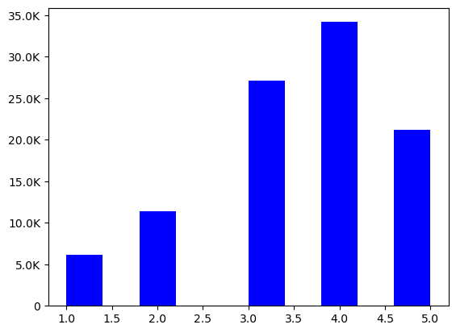

```python
from pyspark_dist_explore import hist

import matplotlib.pyplot as plt

# Plot histogram of ratings
fig, ax = plt.subplots()
hist(ax, df_ratings.select('rating'), bins=10, color=['blue'])
plt.show()
```

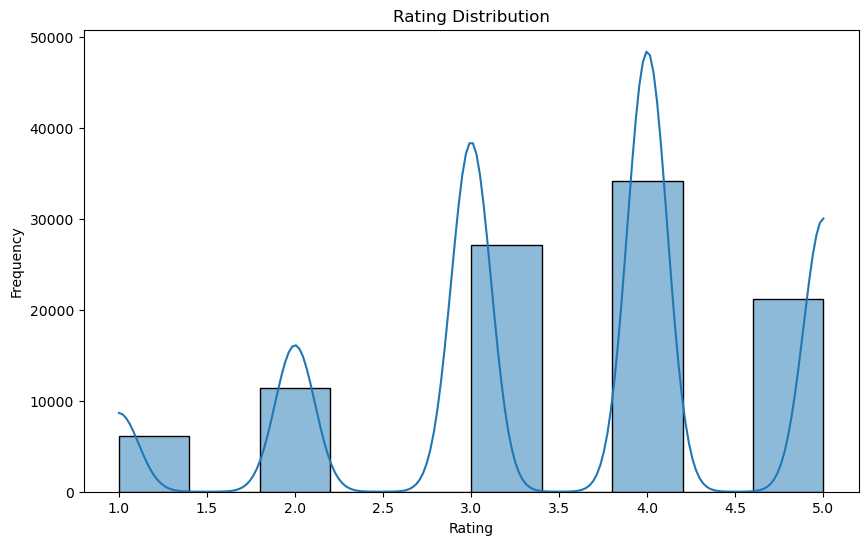

```python
import matplotlib.pyplot as plt
import seaborn as sns

# Convert to Pandas DataFrame
pd_df_ratings = df_ratings.toPandas()

# Plot histogram using seaborn
plt.figure(figsize=(10, 6))
sns.histplot(pd_df_ratings['rating'], bins=10, kde=True)
plt.title('Rating Distribution')
plt.xlabel('Rating')
plt.ylabel('Frequency')
plt.show()
```

pip install handyspark matplotlib

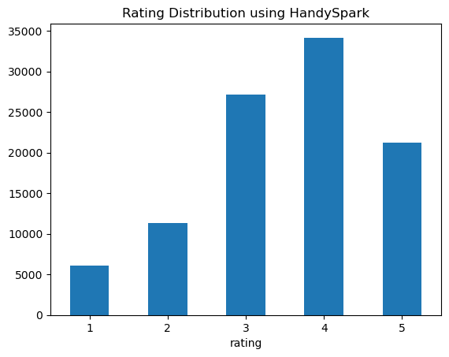

```python
from handyspark import HandyFrame

# Convert to HandyFrame
hdf_ratings = df_ratings.toHandy()

# Plot histogram of ratings
hdf_ratings.cols['rating'].hist()
plt.title('Rating Distribution using HandySpark')
plt.show()
```

## 2.4. Machine Learning with PySpark MLlib

### 2.4.1. Prediction

Step 1: Load the data

```python
from pyspark.sql import SparkSession
from pyspark.sql.types import StructType, StructField, IntegerType, StringType

# Initialize SparkSession
spark = SparkSession.builder.appName("RecommendationModel").getOrCreate()

# Define the schema for the u.data file
schema = StructType([
    StructField("user_id", IntegerType(), True),
    StructField("item_id", IntegerType(), True),
    StructField("rating", IntegerType(), True),
    StructField("timestamp", StringType(), True)
])

# Read the data from the file
df_ratings = spark.read.csv("data/ml-100k/u.data", sep='\t', schema=schema)
```

Step 2: Create an RDD of Rating objects

```python
from pyspark.mllib.recommendation import Rating

# Convert DataFrame to RDD of Rating objects
ratings_rdd = df_ratings.rdd.map(lambda row: Rating(row[0], row[1], row[2]))
```

Step 3: Split the data using randomSplit()

```python
training_rdd, test_rdd = ratings_rdd.randomSplit([0.8, 0.2], seed=42)
```

Step 4: Train the model using ALS

```python
from pyspark.mllib.recommendation import ALS

rank = 10
num_iterations = 10
model = ALS.train(training_rdd, rank, num_iterations)
```

Step 5: Make predictions using the model

```python
# Prepare test data for predictions
testdata = test_rdd.map(lambda x: (x[0], x[1]))

# Make predictions
predictions = model.predictAll(testdata).map(lambda r: ((r[0], r[1]), r[2]))

# Prepare actual ratings for comparison
rates_and_preds = test_rdd.map(lambda r: ((r[0], r[1]), r[2])).join(predictions)
```

Step 6: Evaluate the model

```python
from pyspark.mllib.evaluation import RegressionMetrics

# Compute Mean Squared Error
mse = rates_and_preds.map(lambda r: (r[1][0] - r[1][1])**2).mean()
print("Mean Squared Error = " + str(mse))

# Compute Root Mean Squared Error
rmse = mse**0.5
print("Root Mean Squared Error = " + str(rmse))
```

```
Mean Squared Error = 1.1873740041030294
Root Mean Squared Error = 1.0896669234692908
```

```python
sample_predictions = predictions.take(10)
print("Sample Predictions:")
for prediction in sample_predictions:
    print(prediction)
```

```
Sample Predictions:
((541, 1084), 3.4609574120889803)
((74, 1084), 3.183260482318745)
((526, 1084), 3.3904667093786616)
((50, 1084), 3.0310018833093326)
((194, 1410), 2.1624705731330187)
((890, 667), 2.6618480521042747)
((174, 1053), 4.002383480652458)
((588, 1053), 1.1459677093628593)
((128, 1053), 2.098377676857428)
((286, 1053), 3.566365004127949)
```

**Interpretation** MSE and RMSE: Both MSE and RMSE are indicators of the model's prediction accuracy. Lower values generally indicate better performance.

- In this case, an RMSE of approximately 1.09 suggests that the average deviation between the predicted ratings and the actual ratings is about 1.09. Since movie ratings are typically on a scale from 1 to 5, this error is relatively moderate.
- MSE and RMSE values should be compared against baseline models or other models to determine if this performance is acceptable or if further improvements are needed.

### 2.4.2. Classification

**Logistic Regression**

```python
from pyspark.sql import SparkSession
from pyspark.mllib.regression import LabeledPoint
from pyspark.mllib.feature import HashingTF
from pyspark.mllib.classification import LogisticRegressionWithLBFGS
from pyspark import SparkContext

# Initialize Spark session and context
spark = SparkSession.builder.appName("LogisticRegressionExample").getOrCreate()
sc = SparkContext.getOrCreate()

# Create a synthetic dataset with a clear separation between classes
data = [
    ("I love this movie", 1.0),
    ("This film was terrible", 0.0),
    ("An excellent movie", 1.0),
    ("Awful experience", 0.0),
    ("Will watch again", 1.0),
    ("Not good", 0.0),
    ("Fantastic storyline", 1.0),
    ("Waste of time", 0.0),
    ("Best movie ever", 1.0),
    ("Worst movie ever", 0.0),
]

# Initialize HashingTF
tf = HashingTF(numFeatures=100)

# Transform the data to LabeledPoint
labeled_data = [LabeledPoint(label, tf.transform(text.split())) for text, label in data]

# Split the data into training and test sets
train_data, test_data = sc.parallelize(labeled_data).randomSplit([0.8, 0.2], seed=42)

# Train the logistic regression model
model = LogisticRegressionWithLBFGS.train(train_data)

# Predict on the test data
predictions = model.predict(test_data.map(lambda x: x.features))

# Prepare actual vs prediction for inspection
labels_and_preds = test_data.map(lambda lp: (lp.label, model.predict(lp.features)))

# Show some sample predictions
sample_predictions = labels_and_preds.take(5)
print("Sample Predictions:")
for actual, pred in sample_predictions:
    print(f"Actual: {actual}, Predicted: {pred}")
```

```
Sample Predictions:
Actual: 0.0, Predicted: 1
```

```python
# Initialize Spark session and context
spark = SparkSession.builder.appName("LogisticRegressionMovieLens").getOrCreate()
sc = SparkContext.getOrCreate()

# Load the data
schema = StructType([
    StructField("user_id", IntegerType(), True),
    StructField("item_id", IntegerType(), True),
    StructField("rating", IntegerType(), True),
    StructField("timestamp", StringType(), True)
])
df_ratings = spark.read.csv("data/ml-100k/u.data", sep='\t', schema=schema)

# Convert the DataFrame to RDD and transform ratings to binary labels
data = df_ratings.rdd.map(lambda row: (row[0], row[1], 1.0 if row[2] >= 3 else 0.0))

# Initialize HashingTF
tf = HashingTF(numFeatures=100)

# Transform the data to LabeledPoint
labeled_data = data.map(lambda row: LabeledPoint(row[2], tf.transform([str(row[1])])))

# Split the data into training and test sets
train_data, test_data = labeled_data.randomSplit([0.8, 0.2], seed=42)

# Train the logistic regression model
model = LogisticRegressionWithLBFGS.train(train_data)

# Predict on the test data
predictions = model.predict(test_data.map(lambda x: x.features))

# Prepare actual vs prediction for inspection
labels_and_preds = test_data.map(lambda lp: (lp.label, model.predict(lp.features)))

# Show some sample predictions
sample_predictions = labels_and_preds.take(5)
print("Sample Predictions:")
for actual, pred in sample_predictions:
    print(f"Actual: {actual}, Predicted: {pred}")
```

```
Sample Predictions:
Actual: 1.0, Predicted: 1
Actual: 1.0, Predicted: 1
Actual: 1.0, Predicted: 1
Actual: 0.0, Predicted: 1
Actual: 1.0, Predicted: 1
```

### 2.4.3. Clustering

**Load and prepare the Data**  
File: "WineQT.csv"

```python
from pyspark.sql import SparkSession
from pyspark.sql.types import StructType, StructField, DoubleType, IntegerType
from pyspark.mllib.clustering import KMeans
from pyspark.mllib.linalg import Vectors
import matplotlib.pyplot as plt
from pyspark import SparkContext
import numpy as np
from math import sqrt

# Initialize Spark session and context
spark = SparkSession.builder.appName("KMeansWineQT").getOrCreate()
sc = SparkContext.getOrCreate()

# Define schema for loading the data
schema = StructType([
    StructField("fixed_acidity", DoubleType(), True),
    StructField("volatile_acidity", DoubleType(), True),
    StructField("citric_acid", DoubleType(), True),
    StructField("residual_sugar", DoubleType(), True),
    StructField("chlorides", DoubleType(), True),
    StructField("free_sulfur_dioxide", DoubleType(), True),
    StructField("total_sulfur_dioxide", DoubleType(), True),
    StructField("density", DoubleType(), True),
    StructField("pH", DoubleType(), True),
    StructField("sulphates", DoubleType(), True),
    StructField("alcohol", DoubleType(), True),
    StructField("quality", IntegerType(), True),
    StructField("Id", IntegerType(), True)
])

# Load the wine data
file_path = 'data/WineQT.csv'
df_wine = spark.read.csv(file_path, schema=schema, header=True)

# Create a feature vector for clustering based on citric acid and chlorides
feature_vectors = df_wine.rdd.map(lambda row: Vectors.dense(row.citric_acid, row.chlorides))
```

**Training the K-means Clustering Model**

```python
# Perform K-means clustering
k = 3  # Number of clusters
iterations = 20  # Number of iterations for K-means
model = KMeans.train(feature_vectors, k, maxIterations=iterations)
```

**Evaluate the K-means Model**

```python
# Evaluate the model by computing Within Set Sum of Squared Errors (WSSSE)
def error(point):
    center = model.centers[model.predict(point)]
    return sqrt(sum([x**2 for x in (point - center)]))

wssse = feature_vectors.map(lambda point: error(point)).reduce(lambda x, y: x + y)
print(f"Within Set Sum of Squared Error = {wssse}")
```

```
Within Set Sum of Squared Error = 73.31416057661392
```

**Visualize The K-means Clusters**

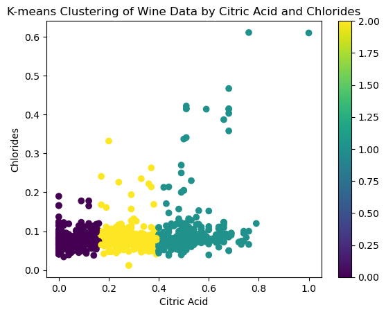

```python
# Collect the results
cluster_assignments = feature_vectors.map(lambda point: model.predict(point)).collect()
data_points = feature_vectors.collect()

# Convert to numpy arrays for plotting
data_points = np.array(data_points)
clusters = np.array(cluster_assignments)

# Plot the results
plt.scatter(data_points[:, 0], data_points[:, 1], c=clusters, cmap="viridis")
plt.xlabel("Citric Acid")
plt.ylabel("Chlorides")
plt.title("K-means Clustering of Wine Data by Citric Acid and Chlorides")
plt.colorbar()
plt.show()
```

```
Within Set Sum of Squared Error = 73.31416057661392
```

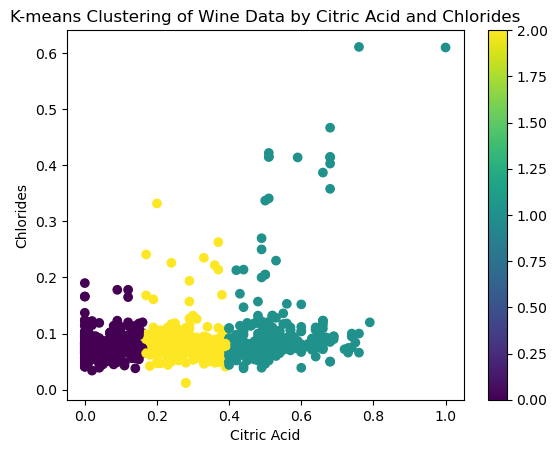

```python
from pyspark.sql import SparkSession
from pyspark.sql.types import StructType, StructField, DoubleType, IntegerType
from pyspark.mllib.clustering import KMeans
from pyspark.mllib.linalg import Vectors
import matplotlib.pyplot as plt
from pyspark import SparkContext
import numpy as np
from math import sqrt

# Initialize Spark session and context
spark = SparkSession.builder.appName("KMeansWineQT").getOrCreate()
sc = SparkContext.getOrCreate()

# Define schema for loading the data
schema = StructType([
    StructField("fixed_acidity", DoubleType(), True),
    StructField("volatile_acidity", DoubleType(), True),
    StructField("citric_acid", DoubleType(), True),
    StructField("residual_sugar", DoubleType(), True),
    StructField("chlorides", DoubleType(), True),
    StructField("free_sulfur_dioxide", DoubleType(), True),
    StructField("total_sulfur_dioxide", DoubleType(), True),
    StructField("density", DoubleType(), True),
    StructField("pH", DoubleType(), True),
    StructField("sulphates", DoubleType(), True),
    StructField("alcohol", DoubleType(), True),
    StructField("quality", IntegerType(), True),
    StructField("Id", IntegerType(), True)
])

# Load the wine data
file_path = 'data/WineQT.csv'
df_wine = spark.read.csv(file_path, schema=schema, header=True)

# Create a feature vector for clustering based on citric acid and chlorides
feature_vectors = df_wine.rdd.map(lambda row: Vectors.dense(row.citric_acid, row.chlorides))

# Perform K-means clustering
k = 3  # Number of clusters
iterations = 20  # Number of iterations for K-means
model = KMeans.train(feature_vectors, k, maxIterations=iterations)

# Evaluate the model by computing Within Set Sum of Squared Errors (WSSSE)
def error(point):
    center = model.centers[model.predict(point)]
    return sqrt(sum([x**2 for x in (point - center)]))

wssse = feature_vectors.map(lambda point: error(point)).reduce(lambda x, y: x + y)
print(f"Within Set Sum of Squared Error = {wssse}")

# Collect the results
cluster_assignments = feature_vectors.map(lambda point: model.predict(point)).collect()
data_points = feature_vectors.collect()

# Convert to numpy arrays for plotting
data_points = np.array(data_points)
clusters = np.array(cluster_assignments)

# Plot the results
plt.scatter(data_points[:, 0], data_points[:, 1], c=clusters, cmap="viridis")
plt.xlabel("Citric Acid")
plt.ylabel("Chlorides")
plt.title("K-means Clustering of Wine Data by Citric Acid and Chlorides")
plt.colorbar()
plt.show()
```

### Extra

```
Test Accuracy = 0.8324873096446701
```

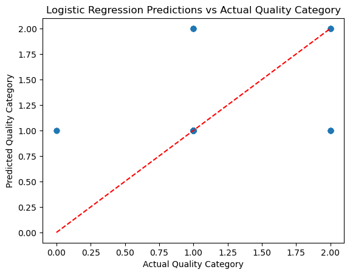

```python
from pyspark.sql import SparkSession
from pyspark.sql.types import StructType, StructField, DoubleType, IntegerType
from pyspark.ml.feature import VectorAssembler
from pyspark.ml.classification import LogisticRegression
from pyspark.ml.evaluation import MulticlassClassificationEvaluator
import matplotlib.pyplot as plt

# Initialize Spark session
spark = SparkSession.builder.appName("WineQualityLogisticRegression").getOrCreate()

# Define schema for loading the data
schema = StructType([
    StructField("fixed_acidity", DoubleType(), True),
    StructField("volatile_acidity", DoubleType(), True),
    StructField("citric_acid", DoubleType(), True),
    StructField("residual_sugar", DoubleType(), True),
    StructField("chlorides", DoubleType(), True),
    StructField("free_sulfur_dioxide", DoubleType(), True),
    StructField("total_sulfur_dioxide", DoubleType(), True),
    StructField("density", DoubleType(), True),
    StructField("pH", DoubleType(), True),
    StructField("sulphates", DoubleType(), True),
    StructField("alcohol", DoubleType(), True),
    StructField("quality", IntegerType(), True),
    StructField("Id", IntegerType(), True)
])

# Load the wine data
file_path = 'data/WineQT.csv'
df_wine = spark.read.csv(file_path, schema=schema, header=True)

# Define a function to categorize the quality
def categorize_quality(quality):
    if quality <= 4:
        return 0  # bad
    elif quality <= 6:
        return 1  # average
    else:
        return 2  # good

# Register the function as a UDF
from pyspark.sql.functions import udf
from pyspark.sql.types import IntegerType

categorize_quality_udf = udf(categorize_quality, IntegerType())

# Apply the UDF to create a new column 'label'
df_wine = df_wine.withColumn("label", categorize_quality_udf(df_wine["quality"]))

# Select features and label
feature_columns = ["fixed_acidity", "volatile_acidity", "citric_acid", "residual_sugar",
                   "chlorides", "free_sulfur_dioxide", "total_sulfur_dioxide", "density",
                   "pH", "sulphates", "alcohol"]
assembler = VectorAssembler(inputCols=feature_columns, outputCol="features")
df_wine = assembler.transform(df_wine)

# Split the data into training and test sets
train_data, test_data = df_wine.randomSplit([0.8, 0.2], seed=42)

# Train a LogisticRegression model
lr = LogisticRegression(featuresCol="features", labelCol="label", maxIter=10)
lr_model = lr.fit(train_data)

# Make predictions
predictions = lr_model.transform(test_data)

# Evaluate the model
evaluator = MulticlassClassificationEvaluator(labelCol="label", predictionCol="prediction", metricName="accuracy")
accuracy = evaluator.evaluate(predictions)
print(f"Test Accuracy = {accuracy}")

# Extract predictions and actual values
predictions_and_labels = predictions.select("prediction", "label").collect()
predicted_values = [row["prediction"] for row in predictions_and_labels]
actual_values = [row["label"] for row in predictions_and_labels]

# Plot predictions vs actual values
plt.scatter(actual_values, predicted_values, alpha=0.5)
plt.plot([min(actual_values), max(actual_values)], [min(actual_values), max(actual_values)], color='red', linestyle='--')
plt.xlabel("Actual Quality Category")
plt.ylabel("Predicted Quality Category")
plt.title("Logistic Regression Predictions vs Actual Quality Category")
plt.show()
```

```
Test Accuracy = 0.6243654822335025
```

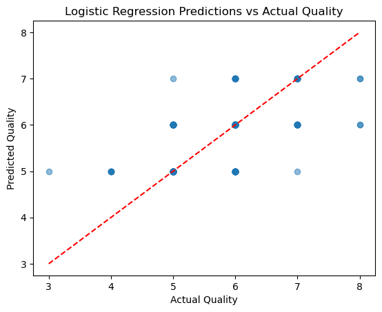

```python
from pyspark.sql import SparkSession
from pyspark.sql.types import StructType, StructField, DoubleType, IntegerType
from pyspark.ml.feature import VectorAssembler
from pyspark.ml.classification import LogisticRegression
from pyspark.ml.evaluation import MulticlassClassificationEvaluator
import matplotlib.pyplot as plt

# Initialize Spark session
spark = SparkSession.builder.appName("WineQualityLogisticRegression").getOrCreate()

# Define schema for loading the data
schema = StructType([
    StructField("fixed_acidity", DoubleType(), True),
    StructField("volatile_acidity", DoubleType(), True),
    StructField("citric_acid", DoubleType(), True),
    StructField("residual_sugar", DoubleType(), True),
    StructField("chlorides", DoubleType(), True),
    StructField("free_sulfur_dioxide", DoubleType(), True),
    StructField("total_sulfur_dioxide", DoubleType(), True),
    StructField("density", DoubleType(), True),
    StructField("pH", DoubleType(), True),
    StructField("sulphates", DoubleType(), True),
    StructField("alcohol", DoubleType(), True),
    StructField("quality", IntegerType(), True),
    StructField("Id", IntegerType(), True)
])

# Load the wine data
file_path = 'data/WineQT.csv'
df_wine = spark.read.csv(file_path, schema=schema, header=True)

# Select features and label
feature_columns = ["fixed_acidity", "volatile_acidity", "citric_acid", "residual_sugar",
                   "chlorides", "free_sulfur_dioxide", "total_sulfur_dioxide", "density",
                   "pH", "sulphates", "alcohol"]
assembler = VectorAssembler(inputCols=feature_columns, outputCol="features")
df_wine = assembler.transform(df_wine)

# Rename 'quality' to 'label' for logistic regression
df_wine = df_wine.withColumnRenamed("quality", "label")

# Split the data into training and test sets
train_data, test_data = df_wine.randomSplit([0.8, 0.2], seed=42)

# Train a LogisticRegression model
lr = LogisticRegression(featuresCol="features", labelCol="label", maxIter=10)
lr_model = lr.fit(train_data)

# Make predictions
predictions = lr_model.transform(test_data)

# Evaluate the model
evaluator = MulticlassClassificationEvaluator(labelCol="label", predictionCol="prediction", metricName="accuracy")
accuracy = evaluator.evaluate(predictions)
print(f"Test Accuracy = {accuracy}")

# Extract predictions and actual values
predictions_and_labels = predictions.select("prediction", "label").collect()
predicted_values = [row["prediction"] for row in predictions_and_labels]
actual_values = [row["label"] for row in predictions_and_labels]

# Plot predictions vs actual values
plt.scatter(actual_values, predicted_values, alpha=0.5)
plt.plot([min(actual_values), max(actual_values)], [min(actual_values), max(actual_values)], color='red', linestyle='--')
plt.xlabel("Actual Quality")
plt.ylabel("Predicted Quality")
plt.title("Logistic Regression Predictions vs Actual Quality")
plt.show()
```

```
Test Accuracy = 0.6700507614213198
```

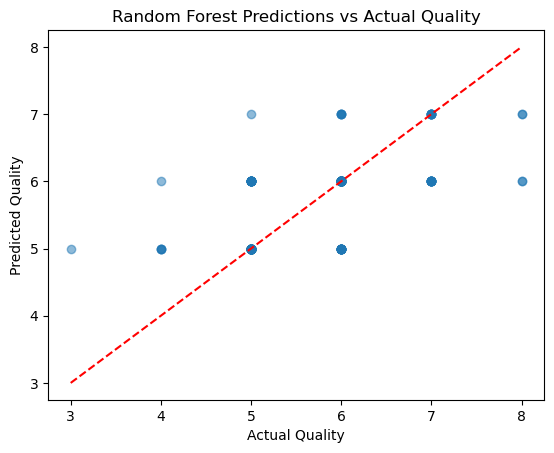

```python
from pyspark.sql import SparkSession
from pyspark.sql.types import StructType, StructField, DoubleType, IntegerType
from pyspark.ml.feature import VectorAssembler
from pyspark.ml.classification import RandomForestClassifier, LinearSVC
from pyspark.ml.evaluation import MulticlassClassificationEvaluator
import matplotlib.pyplot as plt

# Initialize Spark session
spark = SparkSession.builder.appName("WineQualityRandomForest").getOrCreate()

# Define schema for loading the data
schema = StructType([
    StructField("fixed_acidity", DoubleType(), True),
    StructField("volatile_acidity", DoubleType(), True),
    StructField("citric_acid", DoubleType(), True),
    StructField("residual_sugar", DoubleType(), True),
    StructField("chlorides", DoubleType(), True),
    StructField("free_sulfur_dioxide", DoubleType(), True),
    StructField("total_sulfur_dioxide", DoubleType(), True),
    StructField("density", DoubleType(), True),
    StructField("pH", DoubleType(), True),
    StructField("sulphates", DoubleType(), True),
    StructField("alcohol", DoubleType(), True),
    StructField("quality", IntegerType(), True),
    StructField("Id", IntegerType(), True)
])

# Load the wine data
file_path = 'data/WineQT.csv'
df_wine = spark.read.csv(file_path, schema=schema, header=True)

# Select features and label
feature_columns = ["fixed_acidity", "volatile_acidity", "citric_acid", "residual_sugar",
                   "chlorides", "free_sulfur_dioxide", "total_sulfur_dioxide", "density",
                   "pH", "sulphates", "alcohol"]
assembler = VectorAssembler(inputCols=feature_columns, outputCol="features")
df_wine = assembler.transform(df_wine)

# Rename 'quality' to 'label' for classification
df_wine = df_wine.withColumnRenamed("quality", "label")

# Split the data into training and test sets
train_data, test_data = df_wine.randomSplit([0.8, 0.2], seed=42)

# Train a RandomForestClassifier model
rf = RandomForestClassifier(featuresCol="features", labelCol="label", numTrees=100)
rf_model = rf.fit(train_data)

# Make predictions
predictions = rf_model.transform(test_data)

# Evaluate the model
evaluator = MulticlassClassificationEvaluator(labelCol="label", predictionCol="prediction", metricName="accuracy")
accuracy = evaluator.evaluate(predictions)
print(f"Test Accuracy = {accuracy}")

# Extract predictions and actual values
predictions_and_labels = predictions.select("prediction", "label").collect()
predicted_values = [row["prediction"] for row in predictions_and_labels]
actual_values = [row["label"] for row in predictions_and_labels]

# Plot predictions vs actual values
plt.scatter(actual_values, predicted_values, alpha=0.5)
plt.plot([min(actual_values), max(actual_values)], [min(actual_values), max(actual_values)], color='red', linestyle='--')
plt.xlabel("Actual Quality")
plt.ylabel("Predicted Quality")
plt.title("Random Forest Predictions vs Actual Quality")
plt.show()
```

```
Random Forest Test Accuracy after Tuning = 0.6954314720812182
Time taken for training and tuning Random Forest: 1350.9039044380188 seconds
```

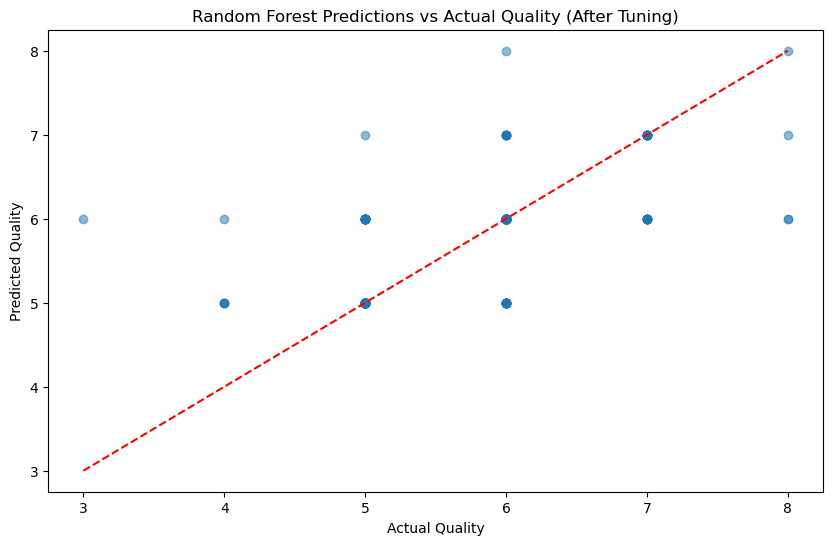

```python
import time
from pyspark.sql import SparkSession
from pyspark.sql.types import StructType, StructField, DoubleType, IntegerType
from pyspark.ml.feature import VectorAssembler, StandardScaler
from pyspark.ml.classification import RandomForestClassifier
from pyspark.ml.evaluation import MulticlassClassificationEvaluator
from pyspark.ml.tuning import CrossValidator, ParamGridBuilder
import matplotlib.pyplot as plt

# Initialize Spark session
spark = SparkSession.builder.appName("WineQualityOptimized").getOrCreate()

# Define schema for loading the data
schema = StructType([
    StructField("fixed_acidity", DoubleType(), True),
    StructField("volatile_acidity", DoubleType(), True),
    StructField("citric_acid", DoubleType(), True),
    StructField("residual_sugar", DoubleType(), True),
    StructField("chlorides", DoubleType(), True),
    StructField("free_sulfur_dioxide", DoubleType(), True),
    StructField("total_sulfur_dioxide", DoubleType(), True),
    StructField("density", DoubleType(), True),
    StructField("pH", DoubleType(), True),
    StructField("sulphates", DoubleType(), True),
    StructField("alcohol", DoubleType(), True),
    StructField("quality", IntegerType(), True),
    StructField("Id", IntegerType(), True)
])

# Load the wine data
file_path = 'data/WineQT.csv'
df_wine = spark.read.csv(file_path, schema=schema, header=True)

# Select features and label
feature_columns = ["fixed_acidity", "volatile_acidity", "citric_acid", "residual_sugar",
                   "chlorides", "free_sulfur_dioxide", "total_sulfur_dioxide", "density",
                   "pH", "sulphates", "alcohol"]
assembler = VectorAssembler(inputCols=feature_columns, outputCol="features")
df_wine = assembler.transform(df_wine)

# Standardize the features
scaler = StandardScaler(inputCol="features", outputCol="scaled_features")
scaler_model = scaler.fit(df_wine)
df_wine = scaler_model.transform(df_wine)

# Rename 'quality' to 'label' for classification
df_wine = df_wine.withColumnRenamed("quality", "label")

# Split the data into training and test sets
train_data, test_data = df_wine.randomSplit([0.8, 0.2], seed=42)

# Define a function to perform cross-validation and parameter tuning
def cross_validation_and_tuning(estimator, param_grid, train_data, evaluator, num_folds=3):
    crossval = CrossValidator(estimator=estimator,
                              estimatorParamMaps=param_grid,
                              evaluator=evaluator,
                              numFolds=num_folds)
    cv_model = crossval.fit(train_data)
    return cv_model

# Start timing the Random Forest training and tuning process
start_time = time.time()

# Random Forest
rf = RandomForestClassifier(featuresCol="scaled_features", labelCol="label")
rf_param_grid = ParamGridBuilder() \
    .addGrid(rf.numTrees, [50, 100, 150, 200]) \
    .addGrid(rf.maxDepth, [5, 10, 15, 20]) \
    .addGrid(rf.maxBins, [32, 64, 128]) \
    .build()
rf_evaluator = MulticlassClassificationEvaluator(labelCol="label", predictionCol="prediction", metricName="accuracy")
rf_cv_model = cross_validation_and_tuning(rf, rf_param_grid, train_data, rf_evaluator)
rf_predictions = rf_cv_model.transform(test_data)
rf_accuracy = rf_evaluator.evaluate(rf_predictions)

# End timing
end_time = time.time()
duration = end_time - start_time
print(f"Random Forest Test Accuracy after Tuning = {rf_accuracy}")
print(f"Time taken for training and tuning Random Forest: {duration} seconds")

# Extract predictions and actual values for RandomForest
rf_predictions_and_labels = rf_predictions.select("prediction", "label").collect()
rf_predicted_values = [row["prediction"] for row in rf_predictions_and_labels]
rf_actual_values = [row["label"] for row in rf_predictions_and_labels]

# Plot predictions vs actual values for RandomForest
plt.figure(figsize=(10, 6))
plt.scatter(rf_actual_values, rf_predicted_values, alpha=0.5)
plt.plot([min(rf_actual_values), max(rf_actual_values)], [min(rf_actual_values), max(rf_actual_values)], color='red', linestyle='--')
plt.xlabel("Actual Quality")
plt.ylabel("Predicted Quality")
plt.title("Random Forest Predictions vs Actual Quality (After Tuning)")
plt.show()
```